# England Blanket Bog Model: Data Preparation: Observations

## Import data —-

```r
list.files(path = "../data/FEP_points")
```

```
 [1] "Catchment_FEP_OS_TrainingPoints_final_clean.dbf"
 [2] "Catchment_FEP_OS_TrainingPoints_final_clean.prj"
 [3] "Catchment_FEP_OS_TrainingPoints_final_clean.qpj"
 [4] "Catchment_FEP_OS_TrainingPoints_final_clean.shp"
 [5] "Catchment_FEP_OS_TrainingPoints_final_clean.shx"
 [6] "FEP_blanket_bog_all.xlsx"
 [7] "FEP_blanket_bog_all_2.xlsx.csv"
 [8] "Landscape_FEP_OS_TrainingPoints_final_clean.dbf"
 [9] "Landscape_FEP_OS_TrainingPoints_final_clean.prj"
[10] "Landscape_FEP_OS_TrainingPoints_final_clean.qpj"
[11] "Landscape_FEP_OS_TrainingPoints_final_clean.shp"
[12] "Landscape_FEP_OS_TrainingPoints_final_clean.shx"
```

```r
FEP_data <- readxl::read_excel("../data/FEP_points/FEP_blanket_bog_all.xlsx", col_names = TRUE)
```

have a look:

```r
dim(FEP_data)
```

```
[1] 144752      7
```

```r
length(unique(FEP_data$PARCREF))
```

```
[1] 53158
```

```r
FEP_data %>%
  filter(grepl("bog", Feature)) %>%
  select(Feature) %>%
  table()
```

```
.
        M06: Blanket bog - BAP habitat W05: Lowland raised bogs - BAP habitat
                                  3919                                    393
```

## Prepare

Convert parcel ref to grid ref

```r
FEP_data$grid_ref <-  paste0(substr(FEP_data$PARCREF, 1, 4), #grid letters and first two x coords
                     substr(FEP_data$PARCREF, 7, 8), #next two x coords
                     substr(FEP_data$PARCREF, 5, 6), #first two y coords
                     substr(FEP_data$PARCREF, 9, 10))#next two y coords
```

Calculate fraction of parcel covered by habitat

```r
FEP_data$hab_cov <- FEP_data$`Feature Quantity` / FEP_data$RLR_AREA
summary(FEP_data$hab_cov)
```

```
     Min.   1st Qu.    Median      Mean   3rd Qu.      Max.      NA's
    0.000     0.166     0.721     4.615     1.000 14750.000      5954
```

Should all be between 0 and 1. Looks like there’s some crazy data in there, but its mostly correct. Check again when I’ve filtered out the blanket bog records.

## Filter

Filter out all blanket bog records where bog greater than 80% cover of parcel

```r
#check extent
FEP_bb <- FEP_data %>%
  filter(grepl("Blanket bog", Feature)) %>%
  filter(hab_cov > 0.8)
summarise(FEP_bb %>% group_by(`Feature UOM`),
          "Feature Count" = length(Feature), uniq_rows = nrow(unique(FEP_bb)),
          PARCREFS = length(unique(PARCREF)),
          min = min(hab_cov), med = median(hab_cov), max = max(hab_cov))
```

| Feature UOM | Feature Count | uniq_rows | PARCREFS | min | med | max |
| --- | --- | --- | --- | --- | --- | --- |
| ha | 389 | 450 | 190 | 0.8018703 | 0.9986484 | 7.501247 |
| m | 14 | 450 | 8 | 0.9231692 | 28.0789146 | 105.594143 |
| NA | 47 | 450 | 21 | 0.8561616 | 0.9911482 | 180.403688 |

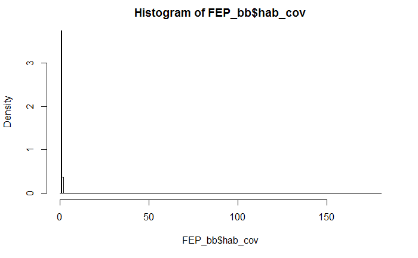

```r
hist(FEP_bb$hab_cov, breaks = c(seq(0, 1, 0.1), seq(2, max(FEP_bb$hab_cov), 50), max(FEP_bb$hab_cov)))
```

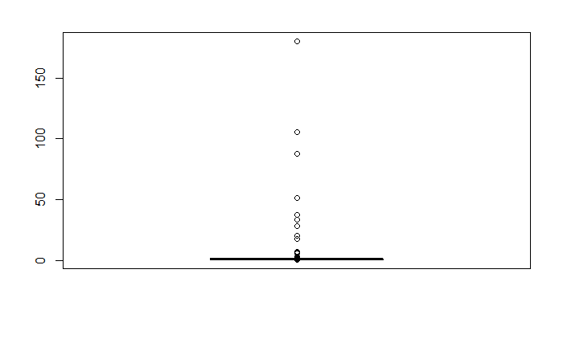

```r
boxplot(FEP_bb$hab_cov)
```

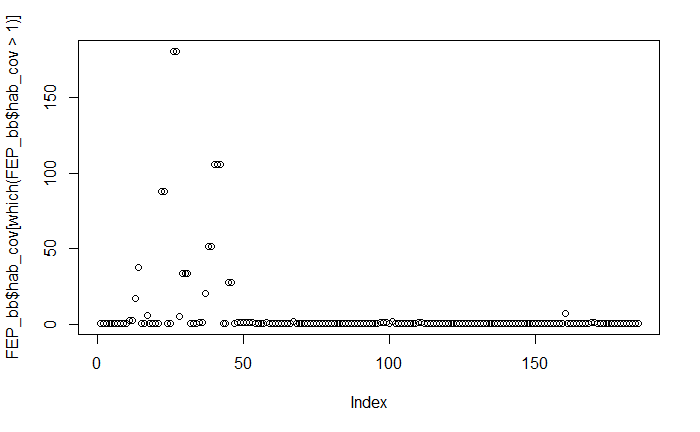

```r
plot(FEP_bb$hab_cov[which(FEP_bb$hab_cov>1)])
```

```r
length(FEP_bb$hab_cov[which(FEP_bb$hab_cov>1)])
```

```
[1] 185
```

```r
length(FEP_bb$hab_cov[which(FEP_bb$hab_cov>1.1)])
```

```
[1] 40
```

so it looks like 185 records show feature cover greater than parcel area, but of those, 145 are only 10% over, so probably a rounding error. However, as this is a small number compared to the global figure of 3919 blanket bog records, we really don’t need to worry too much about it and can just delete them.

```r
length(FEP_bb$PARCREF) - length(unique(FEP_bb$PARCREF))
```

```
[1] 233
```

Also worth noting that there seem to be some duplicate parcel refs so we’ll delete those too.

```r
FEP_bb <- FEP_data %>%
  filter(grepl("Blanket bog", Feature)) %>%
  filter(hab_cov > 0.9, hab_cov <=1) %>%
  filter(`Feature UOM` == "ha") %>%
  select(-OPTCODE) %>%
  distinct()
dim(FEP_bb)
```

```
[1] 72  8
```

```r
dim(FEP_data %>%
  filter(grepl("Blanket bog", Feature)) %>%
  filter(hab_cov > 0.8))
```

```
[1] 450   9
```

ok, that’s maybe deleted too many… hmmm

```r
nrow(FEP_data %>%
  filter(grepl("Blanket bog", Feature)) %>%
  filter(`Feature Quantity` > 0.8) %>%
  distinct()
)
```

```
[1] 3578
```

try another approach: does it cover all of England. Geocoding will take some time, but I can table the first two letters which correspond to grid letters:

```r
FEP_grid_letters <- substr(FEP_data$PARCREF, 1, 2)
table(FEP_grid_letters)
```

```
FEP_grid_letters
   NT    NU    NX    NY    NZ    SD    SE    SJ    SK    SO    SP    SS    ST    SU
  900  1263    87 15340  2530 10829  7778  4171 12522  8945  4469  5546 17974 10534
   SW    SX    SY    SZ    TA    TF    TG    TL    TM    TQ    TR    TV
 2135 10650  3594  1935   678  3392  3696  3579  3030  8092  1002    81
```

```r
table(substr(FEP_bb$PARCREF, 1, 2))
```

[output not shown]

# Export

```r
#write.csv(x = FEP_bb, file = "../data/FEP_bb.csv", row.names = FALSE)
```

# further processing in ArcGIS

- Open csv file in ArcGIS as a layer
- right click and export to dbf
- In ArcCatalog: “\LPHPW0-MPD01-Data_Templates(ArcGIS 10)tools.tbx"
- open GridRefToShape:
  - select dbf file
  - save as FEP_bb.shp
  - select output type: centroids
- spatial join with RLR layer
  - Target features: LIDM_PARCELS_CURRENT
  - Join features: FEP_bb.shp
  - Join operation: JOIN_ONE_TO_ONE
  - Keep all Target Features: false [if set to true will be a huuuge file]
  - match option: INTERSECT
  - output feature class: FEP_bb_RLRparcels.shp
- Create additional presences
  - Create Random Points tool
  - constrain by FEP_bb_RLRparcels.shp
  - 5 points per parcel
  - output feature class: “FEP_bb_random_pts.shp”
- Create non-PHI blanket bog area for training data (if training on a specific area)
  - Erase tool
  - Erase “PHI Blanket Bog” from “England_country.shp”
  - output feature class: “England_no_phibb.shp”
- Create additional absences
  - Create random Points tool
  - constrain by “England_no_phibb.shp”
  - 10000 points
  - output feature class: “Eng_not_bb_random_pts.shp”

```r
list.files(path = "../data", pattern = ".shp")
```

## Import processed data

```r
#save the shapefile into an object
FEP_bb_random_pts_SPDF <- readOGR(dsn = "../data/FEP_bb_random_pts.shp", verbose = TRUE)
not_bb_random_pts_SPDF <- readOGR(dsn = "../data/Eng_not_bb_random_pts.shp", verbose = TRUE)
England_boundary_SPDF <- readOGR(dsn = "../data/England_country.shp", verbose = TRUE)

#remove superfluous column
not_bb_random_pts_SPDF$b_bog <- NULL

#populate with common attribute
FEP_bb_random_pts_SPDF$bbog <- rep("present", nrow(FEP_bb_random_pts_SPDF))
not_bb_random_pts_SPDF$bbog <- rep("absent", nrow(not_bb_random_pts_SPDF))
```

## Prepare

```r
# cut random FEP points to study boundary
#FEP_bb_random_pts_SPDF <- crop(FEP_bb_random_pts_SPDF, extent(YD_pilot_boundary_SPDF))
#plot(FEP_bb_random_pts_SPDF)
#plot(YD_pilot_boundary_SPDF, add = TRUE)
```

```r
#join the presences and absences together in a single dataframe

observations_SPDF <- rbind(FEP_bb_random_pts_SPDF, not_bb_random_pts_SPDF)
observations_SPDF$CID <- NULL
```

```r
table(observations_SPDF$bbog)
```

## export

```r
writeOGR(obj = observations_SPDF, dsn = "../data/FEP_presabs.shp", driver = "ESRI Shapefile", layer = "observations_SPDF")
```